# Project_Part_3

Emily Mendez

11/16/2022

## Table of contents

#### 1. loading data

#### 2. review of last model created

#### 3. splitting data to training and testing

#### 4. Fitting linear model

#### 5. Shrinkage model (elastic)

#### 6. Analyzing Lasso model

#### 7. fitting tree with all variables / plotting

#### 8. pruning tree

#### 9. analyzing and comparing error and accuracy

#### 10. Conclusion

## Review

This dataset is a subset from the United Nations Department of Economics and Social Affairs world population prospect data (a link to this set is provided below). The subsetted Japanese population from 1950 to 2022 dataset contains approximately 73 observations, 55 indicators, and location notes.

Column 6, population density is our response among all other predictor variables.

https://population.un.org/wpp/Download/Standard/MostUsed/

## Loading in data

```r
JapanPop=read.csv('/Users/admin/Documents/Csvv/japan.csv',header=TRUE)
JapanPop=JapanPop[,-13]
indicatorI=read.csv('/Users/admin/Documents/Csvv/Indicator.csv',header=TRUE)
knitr::kable(indicatorI[1:10,1:5],format="markdown")
```

| IndicatorNo | Topic | Indicator | IndicatorName | Unit |
| --- | --- | --- | --- | --- |
| 1 | Population | TPopulation1Jan | Total Population, as of 1 January | thousands |
| 2 | Population | TPopulation1July | Total Population, as of 1 July | thousands |
| 3 | Population | TPopulationMale1July | Male Population, as of 1 July | thousands |
| 4 | Population | TPopulationFemale1July | Female Population, as of 1 July | thousands |
| 5 | Population | PopDensity | Population Density, as of 1 July | persons per square km |
| 6 | Population | PopSexRatio | Population Sex Ratio, as of 1 July | males per 100 females |
| 7 | Population | MedianAgePop | Median Age, as of 1 July | years |
| 8 | Population | NatChange | Natural Change, Births minus Deaths | thousands |
| 9 | Population | NatChangeRT | Rate of Natural Change | per 1,000 population |
| 10 | Population | PopChange | Population Change | thousands |

## Libraries

```r
#loading in libraries
library(tree)
library(caret)
library(Metrics)
library(glmnet)
library(glmnetUtils)
library(MLmetrics)
```

## Final Model from Linear Regression Analysis

```r
#Fitting linear model from project part 2
lin.model=lm(PopDensity~LEx+Births1519+CDR+NetMigrations,data=JapanPop)
summary(lin.model)
```

```
##
## Call:
## lm(formula = PopDensity ~ LEx + Births1519 + CDR + NetMigrations,
##     data = JapanPop)
##
## Residuals:
##      Min       1Q   Median       3Q      Max
## -11.6518  -1.7537   0.1936   2.0634   9.3620
##
## Coefficients:
##                 Estimate Std. Error t value Pr(>|t|)
## (Intercept)   -2.188e+02  1.121e+01 -19.523  < 2e-16 ***
## LEx            6.985e+00  1.354e-01  51.603  < 2e-16 ***
## Births1519     1.022e+00  9.239e-02  11.066  < 2e-16 ***
## CDR           -3.123e+00  2.944e-01 -10.609 4.62e-16 ***
## NetMigrations -4.642e-02  9.709e-03  -4.781 9.72e-06 ***
## ---
## Signif. codes:  0 '***' 0.001 '**' 0.01 '*' 0.05 '.' 0.1 ' ' 1
##
## Residual standard error: 3.818 on 68 degrees of freedom
## Multiple R-squared:  0.9902, Adjusted R-squared:  0.9896
## F-statistic:  1717 on 4 and 68 DF,  p-value: < 2.2e-16
```

The variables used in the model are LEx, Births1519, CDR, and NetMigrations.

- LEx: Life Expectancy at Birth, of both sexes
- Births1519: Births by women aged 15 to 19 in thousands
- CDR: Crude Death Rate deaths per 1,000 population
- NetMigrations: Net Number of Migrants in thousands

*This model was created without data partitioning

## Model Information

```r
#storing for later use
#residual standard error measures sd of residuals
summ1=summary(lin.model)
m1.rsq=summ1$r.squared
m1.rse=summ1$sigma
```

## Data Partitioning

```r
set.seed(123)
trainInx=createDataPartition(JapanPop$Time,times=1,p=0.70,list=FALSE)
training=JapanPop[trainInx,]
testing=JapanPop[-trainInx,]
```

## Fitting Linear model

```r
#testing error
train.lin.m1=lm(PopDensity~LEx+Births1519+CDR+NetMigrations,data=training)
pred.lin.m1=predict(train.lin.m1,newdata = testing[,-6])
m1.MSE = mean( (pred.lin.m1 - testing$PopDensity)^2 )
m1.MSE
```

```
## [1] 16.25858
```

```r
#training error
train.pred=predict(train.lin.m1,newdata=training)
train.MSE.1 = mean( (train.pred - training$PopDensity)^2 )
train.MSE.1
```

```
## [1] 13.60845
```

```r
#summary of data info
sum.1=summary(train.lin.m1)
sum.1$adj.r.squared
```

```
## [1] 0.9893969
```

```r
AIC(train.lin.m1)
```

```
## [1] 300.7741
```

```r
BIC(train.lin.m1)
```

```
## [1] 312.5959
```

## Elastic Net model

```r
#removing top asscociated columns since I did the same in the previous project parts
train.elasNt=cva.glmnet(PopDensity~.,data=training[,-c(1:5)])
```

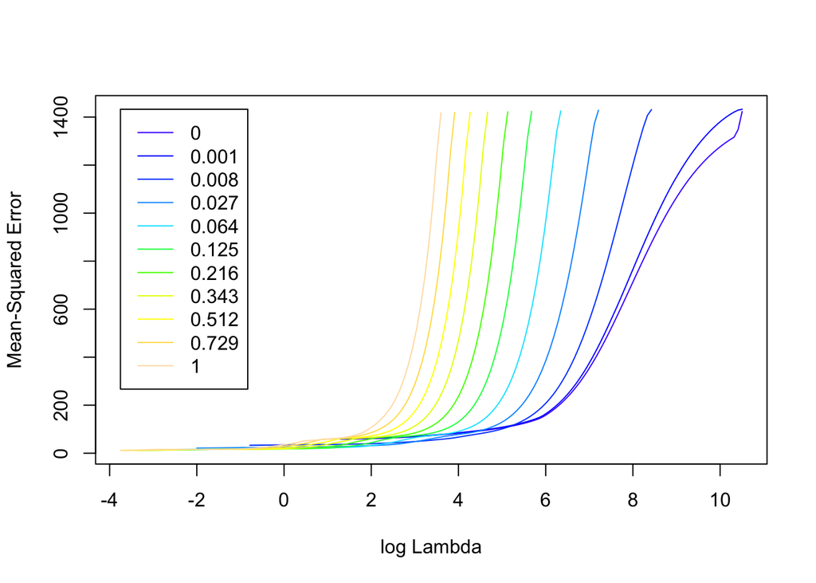

```r
plot(train.elasNt)
```

MSE drastically increases as $\lambda$ approaches 2 or 3.

```r
set.seed(123)
#fitting elastic net model
elasticNet.fit=train(PopDensity~.,data=training[,-c(1:5)],method="glmnet",
                     trControl=trainControl(method = "cv",number=5))
```

```r
#seeing which paramters the model chose
elasticNet.fit
```

```
## glmnet
##
## 53 samples
## 48 predictors
##
## No pre-processing
## Resampling: Cross-Validated (5 fold)
## Summary of sample sizes: 41, 45, 42, 42, 42
## Resampling results across tuning parameters:
##
##   alpha  lambda      RMSE       Rsquared   MAE
##   0.10   0.07306479   4.560961  0.9878309  3.655068
##   0.10   0.73064788   4.560961  0.9878309  3.655068
##   0.10   7.30647879   5.829054  0.9806588  4.886015
##   0.55   0.07306479   3.982087  0.9906280  3.110506
##   0.55   0.73064788   4.077147  0.9902536  3.200943
##   0.55   7.30647879   8.395677  0.9673668  7.579912
##   1.00   0.07306479   3.845437  0.9910995  2.972883
##   1.00   0.73064788   4.882476  0.9865326  3.948911
##   1.00   7.30647879  10.140821  0.9682612  9.116224
##
## RMSE was used to select the optimal model using the smallest value.
## The final values used for the model were alpha = 1 and lambda = 0.07306479.
```

The best model used $\alpha = 1$, therefore is classified as a Lasso model.

```r
#predicting the model with test data/ test error
elnet.pred=predict(elasticNet.fit,newdata = testing[,-c(1:5)])
m2.MSE = mean( (elnet.pred- testing$PopDensity)^2 )
m2.MSE
```

```
## [1] 18.66212
```

```r
#training error
elnet.pred.tr=predict(elasticNet.fit,newdata = training[,-c(1:5)])
train.MSE.2 = mean( (elnet.pred.tr- training$PopDensity)^2 )
train.MSE.2
```

```
## [1] 6.801302
```

## Lasso

```r
#standardizing columns
set.seed(124)
trainingstd= apply(training[,-c(1:5)], 2, function(x){x/sd(x)})
testingstd = apply(testing[,-c(1:5)], 2, function(x){x/sd(x)})
```

```r
#fitting a lasso model
lasso.fit = cv.glmnet(x=trainingstd[,-c(1)], y=trainingstd[,1], alpha=1,type.measure="mse")
```

```r
#looking at the variable selection
print(coef(lasso.fit, s="lambda.1se"))
```

```
## 49 x 1 sparse Matrix of class "dgCMatrix"
##                            s1
## (Intercept)     -2.479222e+01
## PopSexRatio      2.771154e-01
## MedianAgePop     6.223303e-03
## NatChange        .
## NatChangeRT      .
## PopChange        .
## PopGrowthRate    .
## Births           .
## Births1519       4.178018e-02
## CBR             -7.860829e-02
## TFR              .
## NRR              .
## MAC              .
## SRB             -1.831194e-02
## Deaths           .
## DeathsMale       8.017663e-02
## DeathsFemale     .
## CDR             -1.078301e-01
## LEx              .
## LExMale          .
## LExFemale        .
## LE15             .
## LE15Male         .
## LE15Female       1.316306e-01
## LE65             8.454675e-01
## LE65Male         .
## LE65Female       1.314392e-01
## LE80             .
## LE80Male        -1.536262e-01
## LE80Female       .
## InfantDeaths     .
## IMR              .
## LBsurvivingAge1  7.714718e-02
## Under5Deaths     8.540163e-05
## Q5               .
## Q0040            .
## Q0040Male        .
## Q0040Female      .
## Q0060            .
## Q0060Male        .
## Q0060Female      .
## Q1550            .
## Q1550Male        .
## Q1550Female      .
## Q1560            .
## Q1560Male        .
## Q1560Female     -1.763888e-01
## NetMigrations    3.069334e-02
## CNMR             .
```

The features with the largest coefficients are the meaningful features.

Births1519, and CDR were meaningful features used in the lasso model as well as my linear model.

```r
#predicting model with testign data
lasso.pred=predict(lasso.fit,s="lambda.min",newx = testingstd[,-c(1)])

#lasso.fit$lambda.min
```

```r
#test error
m3.MSE= mean((lasso.pred - testingstd[,1])^2)
m3.MSE
```

```
## [1] 12.12193
```

```r
#training error
lasso.pred.tr=predict(lasso.fit,s="lambda.min",newx = trainingstd[,-c(1)])
train.MSE.3= mean((lasso.pred.tr- trainingstd[,1])^2)
train.MSE.3
```

```
## [1] 0.001446642
```

## Decision Tree model

```r
#fitting decision tree
tree.fit=tree(PopDensity~.,data=training[,-c(1:5)])
summary(tree.fit)
```

```
##
## Regression tree:
## tree(formula = PopDensity ~ ., data = training[, -c(1:5)])
## Variables actually used in tree construction:
## [1] "LE65"        "PopSexRatio" "NRR"
## Number of terminal nodes:  5
## Residual mean deviance:  41.03 = 1969 / 48
## Distribution of residuals:
##     Min.  1st Qu.   Median     Mean  3rd Qu.     Max.
## -15.0500  -4.1380   0.2959   0.0000   4.0200  15.1000
```

The tree has 5 nodes. The 3 variables that were picked out to make this specific tree are “LE65”,“PopSexRatio” ,“NRR”.

LE65: Life Expectancy at Age 65, both sexes

PopSexRatio: Population Sex Ratio, as of 1 July

NRR: Net Reproduction Rate; surviving daughters per woman

```r
tree.fit
```

```
## node), split, n, deviance, yval
##       * denotes terminal node
##
## 1) root 53 73690.00 304.9
##   2) LE65 < 15.0061 18  6765.00 257.3
##     4) LE65 < 13.4877 10   960.90 242.3
##       8) PopSexRatio < 96.4434 5    85.15 233.4 *
##       9) PopSexRatio > 96.4434 5    86.92 251.2 *
##     5) LE65 > 13.4877 8   775.50 276.0 *
##   3) LE65 > 15.0061 35  5082.00 329.4
##     6) NRR < 0.81595 27   548.40 335.3 *
##     7) NRR > 0.81595 8   473.60 309.6 *
```

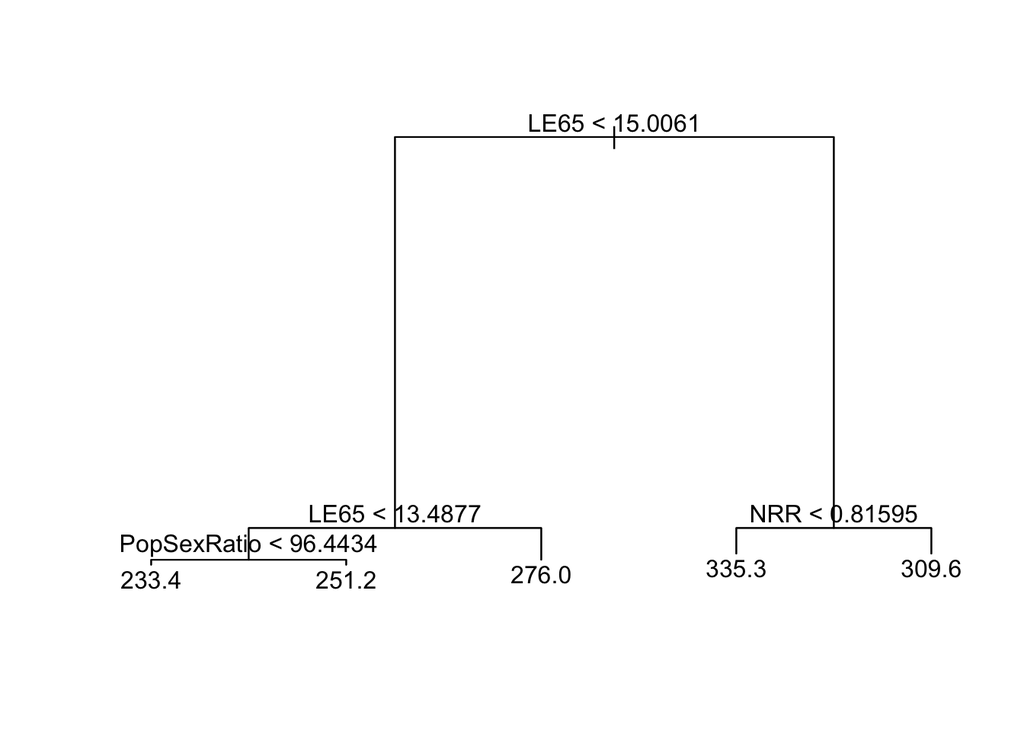

```r
plot(tree.fit)
text(tree.fit,pretty=1)
```

```r
#library(rpart)
#library(rpart.plot)

#tree.fit1=rpart(PopDensity~.,data=training[,-c(1:5)])
#prp(tree.fit1)
```

```r
pred.m1=predict(tree.fit,newdata = testing[,-c(1:5)])
m4.MSE=mean((pred.m1- testing$PopDensity)^2)
m4.MSE
```

```
## [1] 82.89177
```

```r
#training error
pred.train=predict(tree.fit,newdata = training[,-c(1:5)])
train.MSE.4=mean((pred.train- training$PopDensity)^2)
train.MSE.4
```

```
## [1] 37.16031
```

Lets see if we should prune this tree to lower our MSE

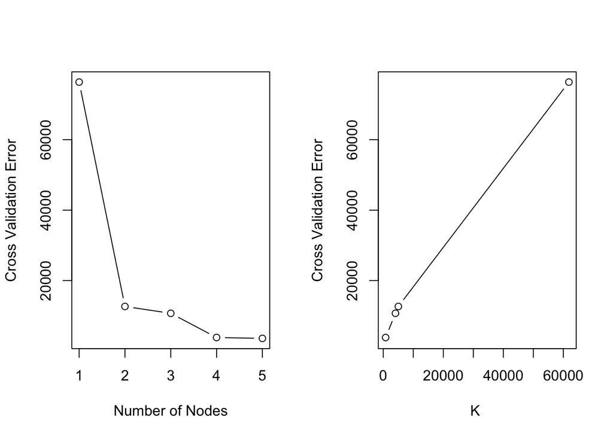

```r
#pruning info
cvTree.m1=cv.tree(tree.fit)
par(mfrow = c(1, 2))
plot(cvTree.m1$size, cvTree.m1$dev, type = "b",xlab="Number of Nodes",ylab = "Cross Validation Error")
plot(cvTree.m1$k, cvTree.m1$dev, type = "b",xlab="K ",ylab = "Cross Validation Error")
```

Our MSE for this decision tree was a lot higher compared to our other models. Unfortunately this is as good as this tree model gets specifically in this partition, these variables and nodes as the cv error is the best at 5 nodes. Further, it would be best to examine multiple trees with a random forest or xgboost to get a better mse for our dataset.

## Results

**Linear Regression**

```r
#linear regression
#R^2 adj
sum.1$adj.r.squared
```

```
## [1] 0.9893969
```

```r
#Test error
m1.MSE
```

```
## [1] 16.25858
```

```r
#training error
train.MSE.1
```

```
## [1] 13.60845
```

**Elastic net**

```r
#elastic net
#R^2
print(1 - m2.MSE / var(testing$PopDensity))
```

```
## [1] 0.9870597
```

```r
#test error
m2.MSE
```

```
## [1] 18.66212
```

```r
#train error
train.MSE.2
```

```
## [1] 6.801302
```

**LASSO**

```r
#Lasso
#R^2
rsq=1 - lasso.fit$cvm /var(trainingstd[,1])
rsq
```

```
##  [1] -0.002548519  0.149260095  0.288057833  0.402669429  0.497356055
##  [6]  0.575885407  0.641353174  0.695574010  0.740795994  0.777974261
## [11]  0.808716539  0.834505675  0.855868906  0.873842995  0.888648637
## [16]  0.900963305  0.911010238  0.919624367  0.928103753  0.935481288
## [21]  0.940871712  0.944990892  0.948405903  0.951248084  0.953621412
## [26]  0.955506071  0.957028664  0.958287287  0.959322555  0.960153283
## [31]  0.961090956  0.962059919  0.963130903  0.964312422  0.965845204
## [36]  0.968104860  0.970756897  0.972853926  0.974678898  0.976551873
## [41]  0.978284258  0.979937905  0.981404828  0.982650769  0.983687259
## [46]  0.984691906  0.985556434  0.986305552  0.987137238  0.987810044
## [51]  0.988285257  0.988574173  0.988830180  0.989033119  0.989224821
## [56]  0.989318720  0.989401037  0.989464827  0.989541291  0.989688741
## [61]  0.989761146  0.989876561  0.989984586  0.990055464  0.990027925
## [66]  0.990074793  0.990134131  0.990182152  0.990230118  0.990315970
## [71]  0.990530022  0.991013343  0.991426904  0.991788335  0.992110684
## [76]  0.992381802  0.992643910  0.992887362  0.993032695  0.993230945
```

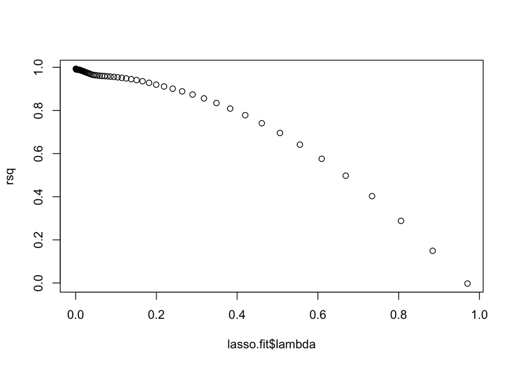

```r
plot(lasso.fit$lambda,rsq)
```

```r
#Lasso
#test error
m3.MSE
```

```
## [1] 12.12193
```

```r
#train error
train.MSE.3
```

```
## [1] 0.001446642
```

**Decision Tree**

```r
#decision tree R^2
print(1 - m4.MSE / var(testing$PopDensity))
```

```
## [1] 0.9425231
```

```r
#test error
m4.MSE
```

```
## [1] 82.89177
```

```r
#train error
train.MSE.4
```

```
## [1] 37.16031
```